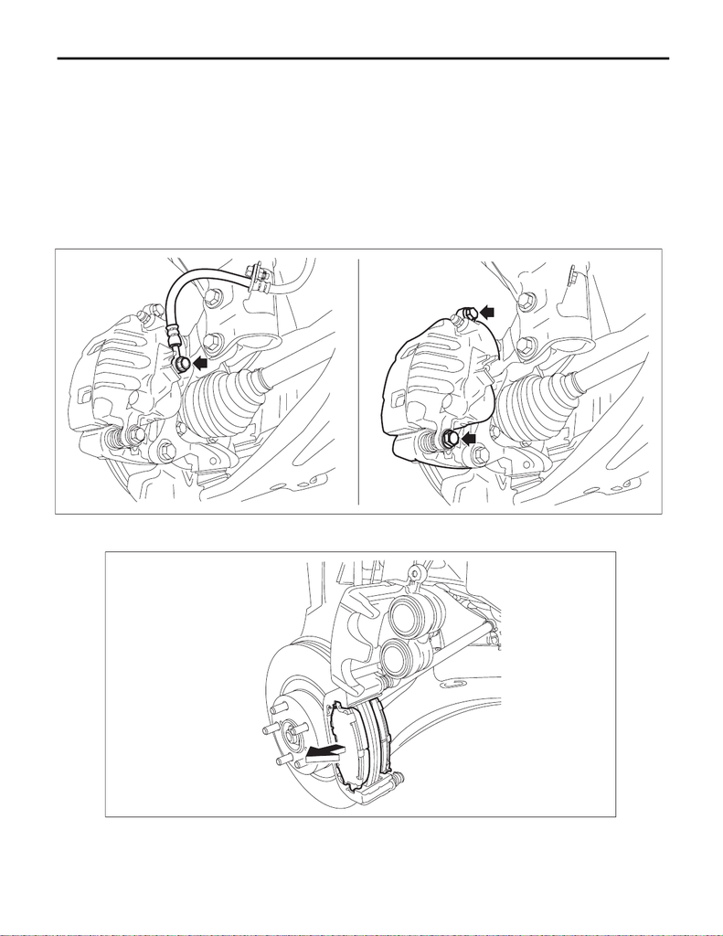

BR-25

Front Disc Brake Assembly

BRAKE

4. Front Disc Brake Assembly

A: REMOVAL

1. EXCEPT FOR STI MODEL

1) Lift up the vehicle, and then remove the front wheels.

2) Remove the union bolt and the caliper bolt, and remove the caliper body assembly.

CAUTION:

• Do not allow brake fluid to come in contact with the painted surface of the vehicle body. If it does,

wash off with water and wipe away completely.

• Prepare a container to catch grease or oil, etc. If any grease or oil spills, wipe it off and clean im-

mediately to prevent from penetrating into floor or flowing outside.

3) Remove the support - front disc brake.

(1) Remove the pad - disc brake front.

BR-01075

BR-00923

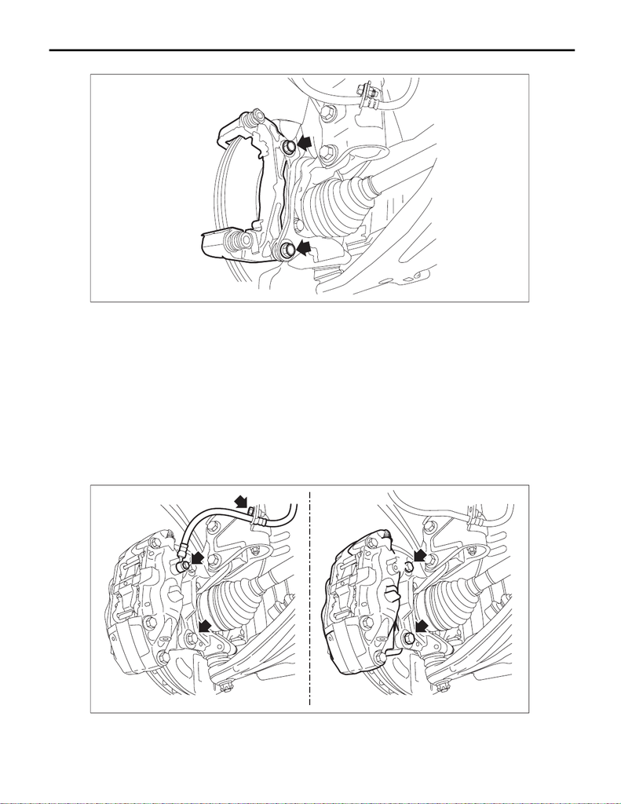

BR-26

Front Disc Brake Assembly

BRAKE

(2) Remove the mounting bolts, and then remove the support - front disc brake.

2. STI MODEL

NOTE:

Before installation, remove mud and foreign matter from the disc brake assembly.

1) Lift up the vehicle, and then remove the front wheels.

2) Remove the pad - disc brake front. <Ref. to BR-17, STI MODEL, REMOVAL, Front Brake Pad.>

3) Remove the union bolt and the caliper bolt, and remove the disc brake assembly.

CAUTION:

• Since the 17-inch (Brembo) caliper body is easily scratched and the paint may be stripped, protect

it from being contacted with other parts or tools.

• Do not allow brake fluid to come in contact with the painted surface of the vehicle body. If it does,

wash off with water and wipe away completely.

• Prepare a container to catch grease or oil, etc. If any grease or oil spills, wipe it off and clean im-

mediately to prevent from penetrating into floor or flowing outside.

BR-00908

BR-01267

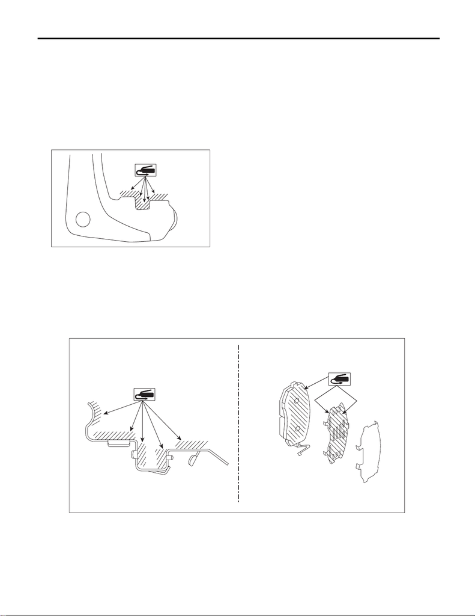

BR-27

Front Disc Brake Assembly

BRAKE

B: INSTALLATION

1. EXCEPT FOR STI MODEL

NOTE:

Before installation, remove mud and foreign matter from the caliper body assembly and support - front disc

brake.

1) Check each part. <Ref. to BR-34, INSPECTION, Front Disc Brake Assembly.>

2) Apply a thin coat of grease to the support - front disc brake.

Grease:

Grease contained in the pad kit or equivalent

3) Install the support - front disc brake.

Tightening torque:

Mounting bolt: 80 N·m (8.2 kgf-m, 59.0 ft-lb)

4) Apply a thin coat of grease to the pad clip, both sides of the shim - disc brake front inner and the shim

mounting surface of the pad - disc brake front.

Grease:

Pad clip (A): An item contained in the pad kit or equivalent

Shim and pad (B): An item contained in the pad kit or Molykote AS880N

BR-00597

BR-01262

(A) (B)

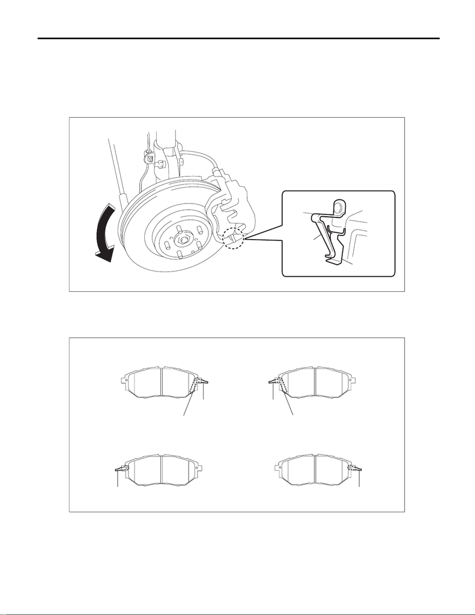

BR-28

Front Disc Brake Assembly

BRAKE

5) Install the brake pad.

CAUTION:

• Be sure to install so that the pad return spring faces the input side of the direction of brake rotor

rotation, as shown in the figure.

• Correctly install the pad return spring to the supporting surface of the pad clip as shown in the fig-

ure.

• If the pad return spring is deformed or damaged, replace the brake pad with a new part.

NOTE:

Install the brake pad indicator in proper direction.

(a) Pad return spring (b) Supporting surface of pad clip (c) Direction of brake rotor rotation

(a) LH — IN (c) RH — IN (e) Pad indicator

(b) LH — OUT (d) RH — OUT (f) Pad return spring

BR-00920

(c)

(a)

(b)

BR-00867

(a)

(b)

(f)

(f)

(f)(f)

(c)

(e)

(e)

(d)

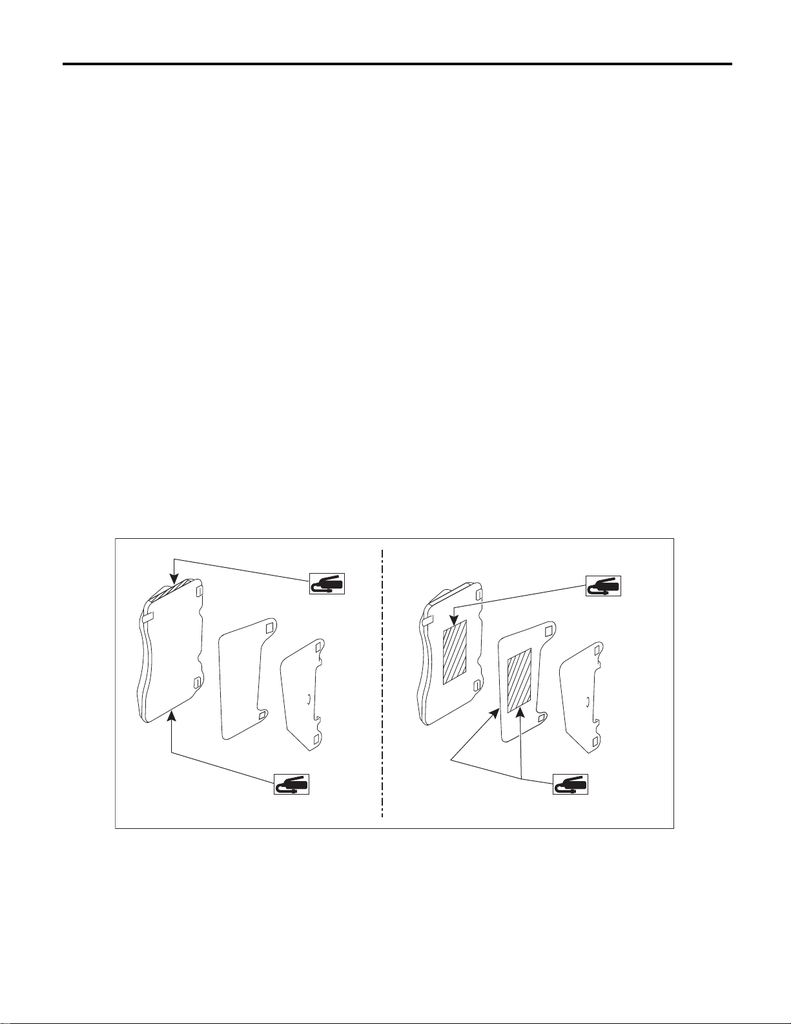

BR-29

Front Disc Brake Assembly

BRAKE

6) Install the caliper body assembly.

Tightening torque:

27 N·m (2.8 kgf-m, 19.9 ft-lb)

7) Connect the brake hose using a new brake hose gasket.

Tightening torque:

26 N·m (2.7 kgf-m, 19.2 ft-lb)

8) Bleed air from the brake system. <Ref. to BR-67, BRAKE LINE, PROCEDURE, Air Bleeding.>

9) Install the front wheels.

Tightening torque:

120 N·m (12.2 kgf-m, 88.5 ft-lb)

2. STI MODEL

NOTE:

Before installation, remove mud and foreign matter from the disc brake assembly.

1) Check each part. <Ref. to BR-34, INSPECTION, Front Disc Brake Assembly.>

2) Install the disc brake assembly.

Tightening torque:

155 N·m (15.8 kgf-m, 114.3 ft-lb)

3) Connect the brake hose using a new brake hose gasket.

Tightening torque:

26 N·m (2.7 kgf-m, 19.2 ft-lb)

4) Apply a thin coat of grease to the side of the pad - disc brake front, both sides of the shim - disc brake front

inner and the shim mounting surface of the pad - disc brake front.

Grease:

Pad side (A): An item contained in the pad kit or equivalent

Shim and pad (B): An item contained in the pad kit or Molykote AS880N

BR-01263

(A) (B)

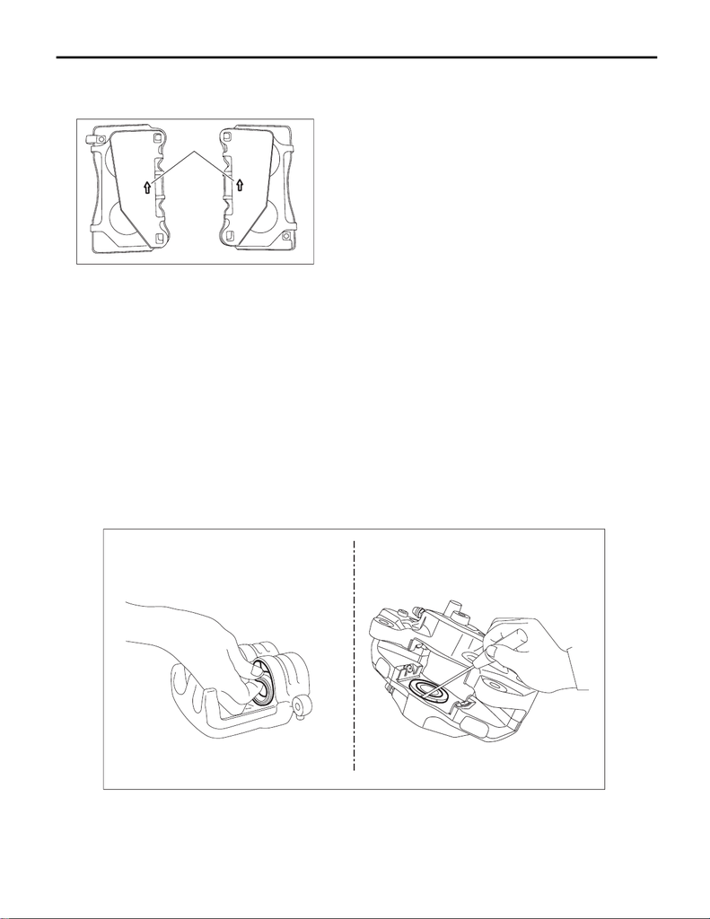

BR-30

Front Disc Brake Assembly

BRAKE

5) Install the pad - disc brake front.

NOTE:

Install so that the arrow (a) faces upward.

6) Install the cross spring.

7) Install the pin - disc brake.

8) Install the clip - slide pin.

9) Bleed air from the brake system. <Ref. to BR-67, BRAKE LINE, PROCEDURE, Air Bleeding.>

10) Install the front wheels.

Tightening torque:

120 N·m (12.2 kgf-m, 88.5 ft-lb)

C: DISASSEMBLY

CAUTION:

• Be careful not to allow foreign matter to enter the brake hose connector.

• Since the 17-inch (Brembo) caliper body is easily scratched and the paint may be stripped, protect

it from being contacted with other parts or tools.

1) Remove mud and foreign matter from the caliper body assembly.

2) Remove the piston boot.

NOTE:

For STI model, remove the four piston boots.

BR-01264

(a)

(A) Except for STI model (B) STI model

BR-01268

(B)(A)

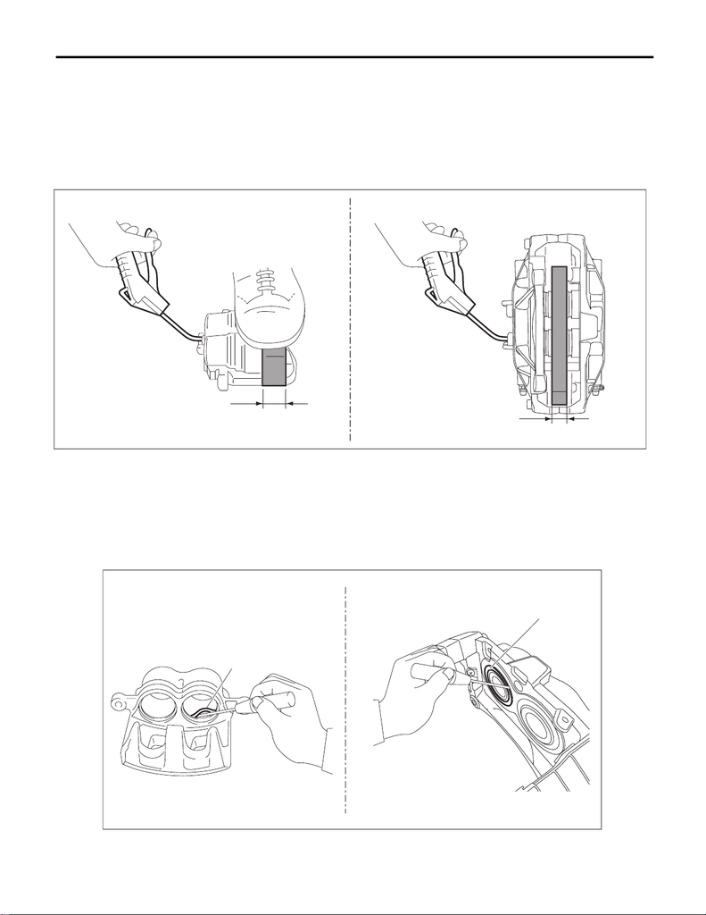

BR-31

Front Disc Brake Assembly

BRAKE

3) Remove the piston - disc brake.

(1) Place a wooden block in the caliper body as shown in the figure to prevent the piston - disc brake from

jumping out and being damaged.

(2) Using an air gun, gradually apply compressed air via the brake hose installation hole to push out the

piston - disc brake.

NOTE:

Instead of removing the pistons one by one, remove all pistons at once after adjusting the amount of protru-

sion evenly using a wooden block.

4) Remove the piston seal (a).

CAUTION:

Do not damage the cylinder and piston seal groove.

NOTE:

For STI model, remove the four piston seals.

(A) Except for STI model (B) STI model

(A) Except for STI model (B) STI model

BR-01269

30 mm (1.18 in)

(A) (B)

30 mm (1.18 in)

BR-01270

(a)

(B)(A)

(a)

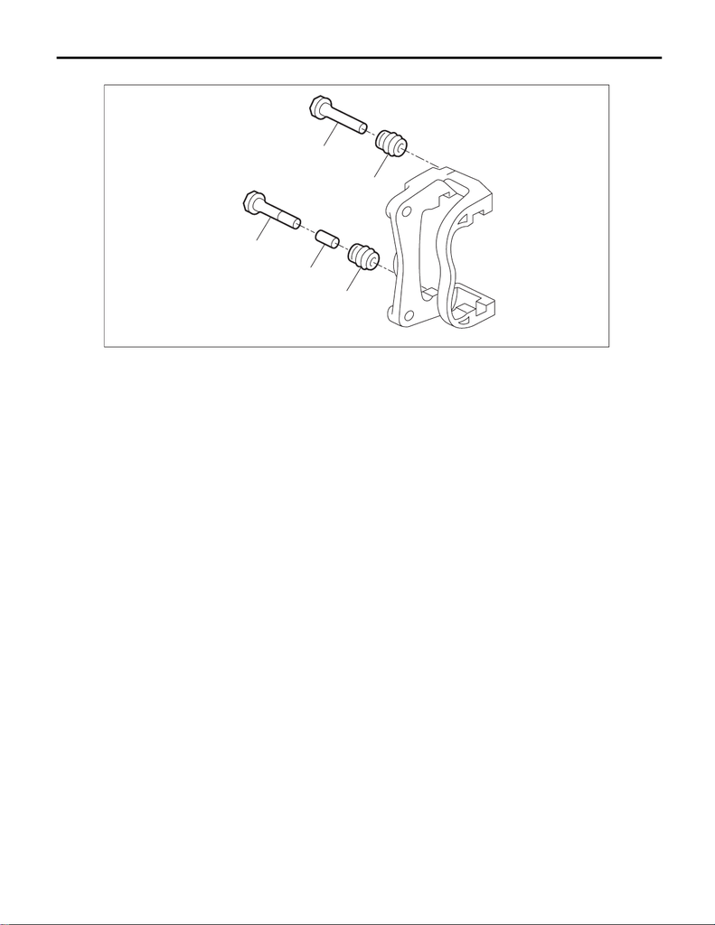

BR-32

Front Disc Brake Assembly

BRAKE

5) Remove each part from support - front disc brake. (Except for STI model)

D: ASSEMBLY

1) Check each part. <Ref. to BR-34, INSPECTION, Front Disc Brake Assembly.>

2) Clean the inside of the caliper body using brake fluid.

Fluid:

FMVSS No. 116, DOT3 or DOT4

3) Install the piston seal and the piston - disc brake.

(1) Apply a coat of brake fluid to piston seal and install the piston seal to the groove inside caliper body.

(2) Apply a coat of brake fluid to the piston sliding part of caliper body and the entire outer surface of the

piston - disc brake.

Fluid:

FMVSS No. 116, DOT3 or DOT4

(3) Apply a coat of grease to the piston boot and fit to the groove on the ends of piston - disc brake.

Grease:

An item contained in the pad kit or Nippon Grease NIGLUBE RX-2

(a) Guide pin - front brake (black) (c) Lock pin - bushing (d) Pin boot

(b) Lock pin - front brake (silver)

BR-00927

(c)

(d)

(d)

(b)

(a)

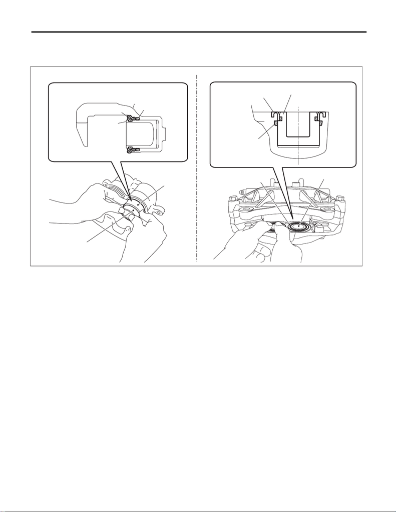

BR-33

Front Disc Brake Assembly

BRAKE

(4) Install the piston - disc brake to the caliper body.

CAUTION:

Do not force the piston - disc brake into the sliding part of caliper body.

4) Apply grease contained in the piston seal kit to the lock pin - front brake, the outer surface of guide pin -

front brake, the pin sliding part of the support - front disc brake, and the grooves of pin boot. (Except for STI

model)

(A) Except for STI model (B) STI model

(a) Piston - disc brake (c) Caliper body

(b) Piston boot (d) Piston seal

BR-01271

(a)

(b)

(b)

(a)

(b)

(c)

(d)

(a)

(a)

(d)

(b)

(B)(A)

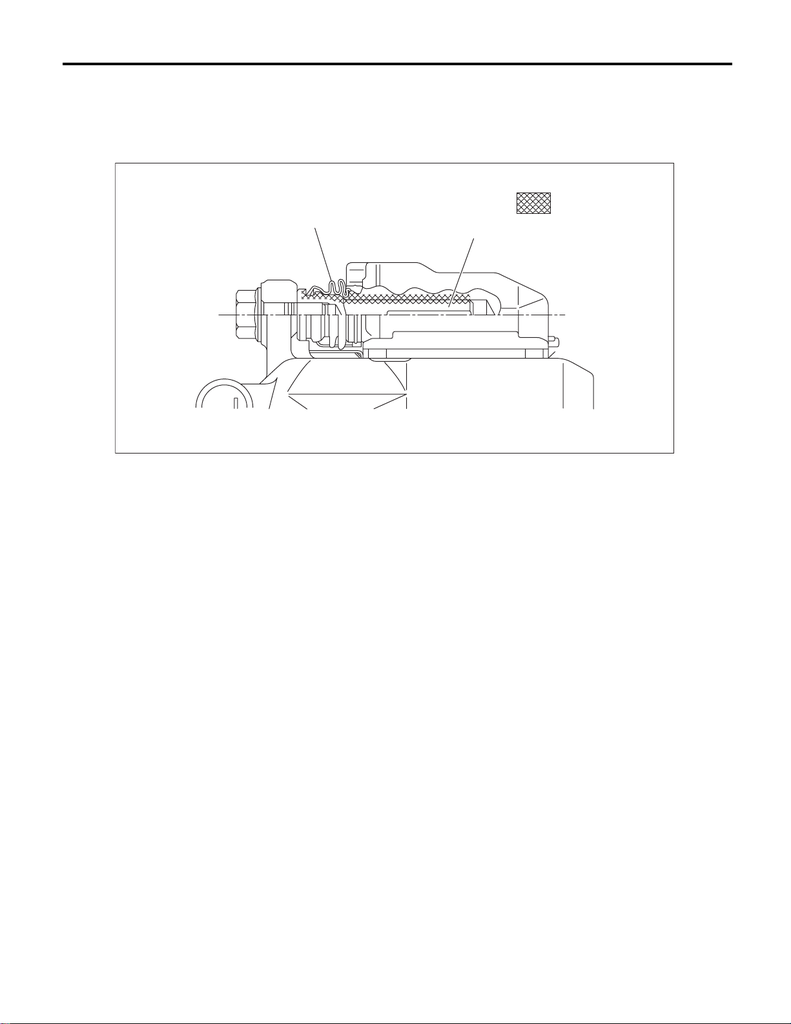

BR-34

Front Disc Brake Assembly

BRAKE

5) Install the pin boot to the lock pin - front brake and the guide pin - front brake, and insert them into the sup-

port - front disc brake. (Except for STI model)

CAUTION:

Insert the lock pin - front brake and guide pin - front brake into specified position, and make sure that

they slide and seat properly.

E: INSPECTION

1) Check the piston sliding part of caliper body and the piston for uneven wear, damage or rust.

2) Check the rubber parts for damage or deterioration.

3) If faulty is found in the inspection, replace the relevant part.

(a) Pin boot (b) Lock pin - front brake or guide pin

- front brake

(c) Grease applied area

(a)

(b)

: (c)

BR-00930